# Notebook

### 1. DESCARGA LIBRERÍAS

```python
import pandas as pd
import numpy as np
import seaborn as sns
import matplotlib.pyplot as plt

from sklearn.preprocessing import MinMaxScaler

from sklearn.model_selection import train_test_split
from sklearn.model_selection import cross_val_score

from xgboost import XGBRegressor
```

### 2. CARGA DE DATOS

En este caso cargamos los datasets sin normalizar y sin aplicar one-hot encoding puesto que no vamos a modelar, simplemente lo queremos para llevar a cabo una segmentación y calcular LGDs medias por segmento.

```python
df_const_cerrados = pd.read_csv('df_const_cerrados_LGD_sin_normalizar.csv')
df_const_abiertos = pd.read_csv('df_const_abiertos_LGD_sin_normalizar.csv')
df_explot_cerrados = pd.read_csv('df_explot_cerrados_LGD_sin_normalizar.csv')
df_explot_abiertos = pd.read_csv('df_explot_abiertos_LGD_sin_normalizar.csv')
```

La diferencia tanto para construcción como para explotación es la variable creada `LGD`

```python
df_const_cerrados.shape, df_const_abiertos.shape
```

```
((41375, 50), (780, 49))
```

```python
df_explot_cerrados.shape, df_explot_abiertos.shape
```

```
((2228, 53), (360, 52))
```

Unificamos los conjuntos de explotación (cerrados y abiertos) como si fueran ambos abiertos, dado que al contar con un periodo de observación de sólo 1 año, los cerrados aún pueden recibir flujos recuperatorios.

```python
#Eliminamos la LGD calculada para los cerrados puesto que no la vamos a necesitar
df_explot_cerrados.drop('LGD', axis=1, inplace=True)
```

```python
#concatenamos
df_explot = pd.concat([df_explot_cerrados, df_explot_abiertos], axis=0)
```

```python
df_explot.shape
```

```
(2588, 52)
```

### 3. SEGMENTADO

El proceso que vamos a seguir es el siguiente:

1. Segmentar **df_const_cerrados** por:
   - `months_last_pymnt_date`: meses que han pasado desde el último pago hasta fecha fin del periodo de observación (es una aproximación del tiempo en default, puesto que no disponemos exacatamente de esa variable en nuestro dataset.
   - `grade_num`: rating interno asignado a dicha operación por la entidad financiera.
   - `term`: plazo original del préstamo (puede ser 36 o 60 meses)
2. Calcular la LGD media para cada segmento.
3. Segmentar **df_const_abiertos** por las mismas variables que los cerrados y aplicar la LGD media calculada para los cerrados para ese segmento.
4. Una vez tengamos un dataframe final llamadado **df_const** con los cerrados más los abiertos, segmentar nuevamente por las mismas variables que anteriormente.
5. Segmentar **df_explot** y aplicar la LGD media calculada en el paso anterior para cada segmento T.
6. Calcular la LGD media total del conjunto de explotación y observar que no es superior al 45%.

3.1 SEGMENTADO DE LOS PROCESOS CERRADOS DE DF_CONSTRUCCIÓN

Crear la segmentación por semestres.  
**IMPORTANTE: la siguiente segmentación crea segmentos de la variable `months_last_pymnt_date`que van de 6 meses en 6 meses, pero tal y cómo hemos estructurado el código, los segmentos van de 0 a 5,9, de 6 a 11,9 y así sucesivamente. Esto será muy importante en cuando apliquemos la segmentación sobre el conjunto de explotación**

```python
# Crear edges desde 0 hasta 66 en pasos de 6 → [0, 6, 12, ..., 66]
bin_edges = list(range(0, 67, 6))  # 67 porque el límite superior del último bin será 66
```

```python
# Crear etiquetas del tipo "0-6 meses", "6-12 meses", ..., "60-66 meses"
bin_labels = [f"{i}-{i+6} meses" for i in bin_edges[:-1]]
```

```python
# Aplicar binning a la variable 'months_last_pymnt_date'
df_const_cerrados["segmento_meses"] = pd.cut(
    df_const_cerrados["months_last_pymnt_date"],
    bins=bin_edges,
    labels=bin_labels,
    right=False,          # Intervalos cerrados por la izquierda, abiertos por la derecha: [a, b)
    include_lowest=True   # Incluye el valor mínimo
)
```

Crear segmentación por 'term_months'

```python
df_const_cerrados["segmento_term"] = df_const_cerrados["term_months"].astype(str)
```

Agrupar por segmento de meses, grade_num y term_months para calcular LGD media

```python
lgd_media_segmentos = df_const_cerrados.groupby(["segmento_meses", "grade_num", "segmento_term"])["LGD"].mean().reset_index()
```

```python
lgd_media_segmentos
```

|  | segmento_meses | grade_num | segmento_term | LGD |
| --- | --- | --- | --- | --- |
| 0 | 0-6 meses | 1 | 36 | 0.0 |
| 1 | 0-6 meses | 1 | 60 | 0.0 |
| 2 | 0-6 meses | 2 | 36 | 0.0 |
| 3 | 0-6 meses | 2 | 60 | 0.0 |
| 4 | 0-6 meses | 3 | 36 | 0.0 |
| ... | ... | ... | ... | ... |
| 149 | 60-66 meses | 5 | 60 | 0.0 |
| 150 | 60-66 meses | 6 | 36 | NaN |
| 151 | 60-66 meses | 6 | 60 | 0.2 |
| 152 | 60-66 meses | 7 | 36 | NaN |
| 153 | 60-66 meses | 7 | 60 | 0.0 |

154 rows × 4 columns

Crear tabla pivote con segmentación por term_months y grade_num en el eje Y, y segmento_meses en el eje X

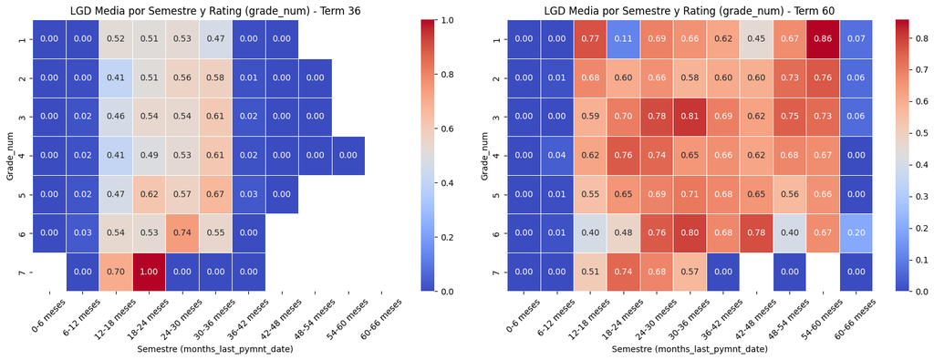

```python
# Filtrar datos para term = 36 y term = 60
lgd_term_36 = lgd_media_segmentos[lgd_media_segmentos["segmento_term"] == "36"]
lgd_term_60 = lgd_media_segmentos[lgd_media_segmentos["segmento_term"] == "60"]

# Crear figuras
fig, axes = plt.subplots(1, 2, figsize=(16, 6))

# Heatmap para term = 36
pivot_36 = lgd_term_36.pivot(index="grade_num", columns="segmento_meses", values="LGD")
sns.heatmap(pivot_36, annot=True, cmap="coolwarm", fmt=".2f", linewidths=0.5, ax=axes[0])
axes[0].set_title("LGD Media por Semestre y Rating (grade_num) - Term 36")
axes[0].set_xlabel("Semestre (months_last_pymnt_date)")
axes[0].set_ylabel("Grade_num")
axes[0].tick_params(axis='x', rotation=45)

# Heatmap para term = 60
pivot_60 = lgd_term_60.pivot(index="grade_num", columns="segmento_meses", values="LGD")
sns.heatmap(pivot_60, annot=True, cmap="coolwarm", fmt=".2f", linewidths=0.5, ax=axes[1])
axes[1].set_title("LGD Media por Semestre y Rating (grade_num) - Term 60")
axes[1].set_xlabel("Semestre (months_last_pymnt_date)")
axes[1].set_ylabel("Grade_num")
axes[1].tick_params(axis='x', rotation=45)

# Mostrar gráficos
plt.tight_layout()
plt.show()
```

De las tablas anteriores se pueden extraer algunas preguntas:

**¿Por qué las LGDs empiezan a ser positivas a partir de los 12 meses?**

1. Posible retraso en las recuperaciones:
   - En préstamos en default, los cobros de recuperaciones suelen ocurrir con cierto retardo (judicialización, renegociaciones, ventas de cartera, etc.).
   - Esto podría explicar por qué en los primeros 12 meses la LGD es baja o nula, ya que todavía no se han realizado cobros suficientes para calcular una LGD significativa.
2. Criterios de default y recobro:
   - Puede ser que hasta los 12 meses muchos préstamos en default sigan en un estado "pendiente de cobro", sin un dato definitivo de pérdidas.
   - A partir del año 1, los préstamos pueden haber entrado en procesos de cobro más efectivos.

**¿Por qué la LGD se extiende hasta el plazo del préstamo (36 o 60 meses)?**

1. El plazo de recuperación suele estar relacionado con el plazo del préstamo:
   - En muchos casos, los esfuerzos de cobro se extienden hasta el vencimiento del préstamo original.
   - Si un préstamo de 36 meses entra en default temprano (ej. mes 6), la entidad podría intentar recuperaciones hasta que el préstamo original hubiera terminado (mes 36).
   - Lo mismo ocurre con los de 60 meses, donde la entidad sigue intentando recuperar hasta que el préstamo habría finalizado.
2. Posible efecto de la cancelación de datos:
   - Puede que, después del plazo original del préstamo, los datos sobre LGD ya no se sigan reportando porque:
     - Se ha cerrado la cuenta contablemente.
     - Se han vendido los préstamos en default a un tercero.
     - No hay más actividad relevante después de ese plazo.

Evolución de la LGD media de cada tipo de préstamo (term=36 y term=60) sin segmentar por 'Grade_num'

```python
# Agrupar por segmento de meses y term_months para calcular LGD media
lgd_media_segmentos_graf = df_const_cerrados.groupby(["segmento_meses", "segmento_term"])\
    ["LGD"].mean().reset_index()
```

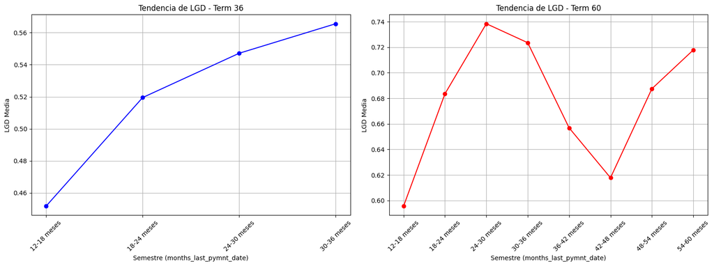

```python
# Filtrar datos para term = 36 y term = 60 desde el mes 12-18 en adelante
lgd_term_36 = lgd_media_segmentos_graf[(lgd_media_segmentos_graf["segmento_term"] == "36") &
                                  (lgd_media_segmentos_graf["segmento_meses"] >= "12-18 meses") &
                                  (lgd_media_segmentos_graf["segmento_meses"] <= "30-36 meses")]

lgd_term_60 = lgd_media_segmentos_graf[(lgd_media_segmentos_graf["segmento_term"] == "60") &
                                  (lgd_media_segmentos_graf["segmento_meses"] >= "12-18 meses") &
                                  (lgd_media_segmentos_graf["segmento_meses"] <= "54-60 meses")]

# Ordenar los datos correctamente
lgd_term_36 = lgd_term_36.sort_values(by="segmento_meses")
lgd_term_60 = lgd_term_60.sort_values(by="segmento_meses")

# Crear figuras
fig, axes = plt.subplots(1, 2, figsize=(16, 6))

# Gráfico de líneas para term = 36
axes[0].plot(lgd_term_36["segmento_meses"], lgd_term_36["LGD"], marker="o", linestyle="-", color="b")
axes[0].set_title("Tendencia de LGD - Term 36")
axes[0].set_xlabel("Semestre (months_last_pymnt_date)")
axes[0].set_ylabel("LGD Media")
axes[0].tick_params(axis='x', rotation=45)
axes[0].grid(True)

# Gráfico de líneas para term = 60
axes[1].plot(lgd_term_60["segmento_meses"], lgd_term_60["LGD"], marker="o", linestyle="-", color="r")
axes[1].set_title("Tendencia de LGD - Term 60")
axes[1].set_xlabel("Semestre (months_last_pymnt_date)")
axes[1].set_ylabel("LGD Media")
axes[1].tick_params(axis='x', rotation=45)
axes[1].grid(True)

# Mostrar gráficos
plt.tight_layout()
plt.show()
```

Observamos cómo el comportamiento de las LGDs es errático y se incrementa con el paso del tiempo en default (lo habitual es que con el paso del tiempo las recuperaciones se incrementen y en consecuencia la LGD disminuya), lo cuál puede ser una prueba clara de que la variable `months_last_pymnt_date`no es el tiempo en default, sino simplemente los meses que han transcurrido desde que el último pago fue recibido:

1. Préstamos con `months_last_pymnt_date` bajo pueden estar en default hace tiempo: Un préstamo con último pago hace 6 meses podría haber entrado en default hace 12 o 24 meses, si antes hizo pagos irregulares.
2. Los préstamos con `months_last_pymnt_date` alto podrían haber hecho un último pago parcial: Un préstamo con months_last_pymnt_date = 36 no significa que haya estado 36 meses en default, sino que hizo su último pago hace 36 meses.

En cualquier caso, pese a que la variable `months_last_pymnt_date` no represente el tiempo en default del préstamo, se trata de una segmentación válida para aplicar a los procesos recuperatorios abiertos, puesto que:

- Es consistente → Usa variables disponibles (months_last_pymnt_date, term_months).
- Tiene suficiente granularidad → Separa por plazo (term=36 o 60) y tiempo desde el último pago.
- Proporciona una LGD media estable → Permite asignar un valor basado en datos históricos.

# POSIBLE MEJORA: LLEVAR A CABO VALIDACIONES PARA LOS SEGMENTOS CREADOS AL IGUAL QUE HICIMOS CON LA PD

3.2 APLICAR LGD MEDIA DE LOS PROCESOS RECUPERATORIOS CERRADOS A LOS PROCESOS ABIERTOS DE DF_CONSTRUCCIÓN

En primer lugar vamos a agregar 2 columnas a la variable `lgd_media_segmentos` calculada anteriormente, que nos muestre el número de préstamos empleados en el cálculo de la LGD media y el % que representan sobre el total de la muestra, para considerar cómo representativa dicha LGD calculada.

```python
# # Calcular el total de muestras
# total_muestras = len(df_const_cerrados)

# # Agrupar por segmento de meses y term_months para calcular LGD media y % de muestras utilizadas
# lgd_media_segmentos_mean = df_const_cerrados.groupby(["segmento_meses", "segmento_term"]).agg(
#     LGD_mean=("LGD", "mean"),
#     muestras_utilizadas=("LGD", "count")
# ).reset_index()

# # Calcular el % de muestras utilizadas sobre el total
# lgd_media_segmentos_mean["pct_muestras_utilizadas"] = (lgd_media_segmentos_mean["muestras_utilizadas"] / total_muestras) * 100
```

```python
# Calcular el total de muestras
total_muestras = len(df_const_cerrados)

# Agrupar por segmento de meses y term_months para calcular LGD media y % de muestras utilizadas
lgd_media_segmentos= df_const_cerrados.groupby(["segmento_meses", "grade_num", "segmento_term"]).agg(
    LGD_mean=("LGD", "mean"),
    muestras_utilizadas=("LGD", "count")
).reset_index()
```

```python
lgd_media_segmentos
```

|  | segmento_meses | grade_num | segmento_term | LGD_mean | muestras_utilizadas |
| --- | --- | --- | --- | --- | --- |
| 0 | 0-6 meses | 1 | 36 | 0.0 | 297 |
| 1 | 0-6 meses | 1 | 60 | 0.0 | 11 |
| 2 | 0-6 meses | 2 | 36 | 0.0 | 493 |
| 3 | 0-6 meses | 2 | 60 | 0.0 | 58 |
| 4 | 0-6 meses | 3 | 36 | 0.0 | 418 |
| ... | ... | ... | ... | ... | ... |
| 149 | 60-66 meses | 5 | 60 | 0.0 | 20 |
| 150 | 60-66 meses | 6 | 36 | NaN | 0 |
| 151 | 60-66 meses | 6 | 60 | 0.2 | 5 |
| 152 | 60-66 meses | 7 | 36 | NaN | 0 |
| 153 | 60-66 meses | 7 | 60 | 0.0 | 1 |

154 rows × 5 columns

Nos quedamos sólo con aquellos segmentos dónde su LGD media ha sido calculada con al menos 30 muestras.

```python
lgd_media_segmentos = lgd_media_segmentos[lgd_media_segmentos['muestras_utilizadas']>30]
lgd_media_segmentos
```

|  | segmento_meses | grade_num | segmento_term | LGD_mean | muestras_utilizadas |
| --- | --- | --- | --- | --- | --- |
| 0 | 0-6 meses | 1 | 36 | 0.000000 | 297 |
| 2 | 0-6 meses | 2 | 36 | 0.000000 | 493 |
| 3 | 0-6 meses | 2 | 60 | 0.000000 | 58 |
| 4 | 0-6 meses | 3 | 36 | 0.000000 | 418 |
| 5 | 0-6 meses | 3 | 60 | 0.000000 | 135 |
| ... | ... | ... | ... | ... | ... |
| 129 | 54-60 meses | 2 | 60 | 0.761905 | 63 |
| 131 | 54-60 meses | 3 | 60 | 0.730769 | 52 |
| 133 | 54-60 meses | 4 | 60 | 0.666667 | 42 |
| 135 | 54-60 meses | 5 | 60 | 0.656250 | 32 |
| 143 | 60-66 meses | 2 | 60 | 0.062500 | 32 |

90 rows × 5 columns

Asignar la LGD media que le corresponde a su segmento a cada operación (teniendo en cuenta que dicha LGD media ha sido calculada con suficientes muestras) a los procesos recuperatorios cerrados.

```python
def asignar_lgd(row):
    filtro = (
        (lgd_media_segmentos["segmento_meses"] == row["segmento_meses"]) &
        (lgd_media_segmentos["segmento_term"] == row["segmento_term"])
    )
    resultado = lgd_media_segmentos[filtro]["LGD_mean"].values
    return resultado[0] if len(resultado) > 0 else "No hay datos para estimar"
```

```python
df_const_cerrados["LGD_asignada"] = df_const_cerrados.apply(asignar_lgd, axis=1)
```

Observamos que la media de la cartera para los procesos recuperatorios cerrados del conjunto de construcción es de un 41,2%

```python
lgd_asignada_numerica = pd.to_numeric(df_const_cerrados["LGD_asignada"], errors='coerce')
media_lgd_asignada = lgd_asignada_numerica.mean()
media_lgd_asignada
```

```
0.4118181853854055
```

En primer lugar debemos segmentar la cartera de los abiertos igual que hicimos para los cerrados, para posteriormente aplicar la LGD que le corresponda a su segmento.

```python
# Aplicar binning a la variable 'months_last_pymnt_date'
df_const_abiertos["segmento_meses"] = pd.cut(
    df_const_abiertos["months_last_pymnt_date"],
    bins=bin_edges,
    labels=bin_labels,
    right=False,          # Intervalos cerrados por la izquierda, abiertos por la derecha: [a, b)
    include_lowest=True   # Incluye el valor mínimo
)
```

```python
#columna segmento plazo del préstamo

df_const_abiertos["segmento_term"] = df_const_abiertos["term_months"].astype(str)
```

Aplicamos la segmentación calculada previamente a los procesos recuperatorios abiertos del conjunto de construcción.

```python
df_const_abiertos["LGD_asignada"] = df_const_abiertos.apply(asignar_lgd, axis=1)
```

**La LGD media para los procesos recuperatorios abiertos del conjunto de construcción es de 46%**

```python
lgd_asignada_numerica = pd.to_numeric(df_const_abiertos["LGD_asignada"], errors='coerce')
media_lgd_asignada = lgd_asignada_numerica.mean()
media_lgd_asignada
```

```
0.46027897461015665
```

```python
df_const_cerrados.shape, df_const_abiertos.shape
```

```
((41375, 53), (780, 52))
```

Eliminamos la columna LGD y concatenamos los 2 conjuntos de datos, abiertos y cerrados

```python
df_const_cerrados.drop('LGD', axis=1, inplace=True)
```

```python
df_const = pd.concat([df_const_cerrados, df_const_abiertos], axis=0)
```

```python
df_const.shape
```

```
(42155, 52)
```

Del conjunto de datos final de construcción, existen 26 préstamos que no hemos podido estimar por falta de cantidad de muestras para calcular su media. Ya que representan un número muy bajo sobre el total de muestras, vamos a eliminarlas para que no distorsionen el cálculo.

```python
rows_to_drop = df_const[df_const["LGD_asignada"]=="No hay datos para estimar"]
rows_to_drop
```

|  | loan_amnt | funded_amnt | funded_amnt_inv | int_rate | installment | annual_inc | pymnt_plan | purpose | dti | delinq_2yrs | ... | months_last_pymnt_date | last_credit_pull_date | months_last_credit_pull_date | filtered_emp_title | zip_code_grouped | addr_state_grouped | loan_status | segmento_meses | segmento_term | LGD_asignada |
| --- | --- | --- | --- | --- | --- | --- | --- | --- | --- | --- | --- | --- | --- | --- | --- | --- | --- | --- | --- | --- | --- |
| 7 | 15000 | 15000 | 8725.000000 | 14.27 | 514.64 | 60000.0 | n | debt_consolidation | 15.22 | 0.0 | ... | 49 | 2016-01-01 | 49 | other | 0 | 1 | Charged Off | 48-54 meses | 36 | No hay datos para estimar |
| 1041 | 4800 | 4800 | 4800.000000 | 14.27 | 164.69 | 48000.0 | n | debt_consolidation | 21.88 | 0.0 | ... | 52 | 2012-03-01 | 6 | other | 0 | 1 | Charged Off | 48-54 meses | 36 | No hay datos para estimar |
| 2082 | 5000 | 5000 | 4175.000000 | 16.49 | 177.00 | 24000.0 | n | debt_consolidation | 16.10 | 4.0 | ... | 56 | 2016-01-01 | 56 | other | 0 | 2 | Charged Off | 54-60 meses | 36 | No hay datos para estimar |
| 2410 | 6625 | 6625 | 6625.000000 | 16.40 | 234.23 | 36000.0 | n | debt_consolidation | 23.10 | 1.0 | ... | 42 | 2015-12-01 | 56 | other | 0 | 1 | Charged Off | 42-48 meses | 36 | No hay datos para estimar |
| 3406 | 13000 | 11250 | 11123.117820 | 6.91 | 346.91 | 62000.0 | n | medical | 15.41 | 0.0 | ... | 43 | 2014-04-01 | 42 | other | 0 | 2 | Charged Off | 42-48 meses | 36 | No hay datos para estimar |
| 3833 | 9800 | 9800 | 9475.000000 | 7.88 | 306.56 | 55000.0 | n | debt_consolidation | 24.17 | 0.0 | ... | 42 | 2014-01-01 | 42 | other | 0 | -1 | Charged Off | 42-48 meses | 36 | No hay datos para estimar |
| 4016 | 4750 | 4750 | 4750.000000 | 14.72 | 164.01 | 10400.0 | n | small_business | 3.00 | 3.0 | ... | 67 | 2010-11-01 | 5 | teacher | 0 | 2 | Charged Off | NaN | 36 | No hay datos para estimar |
| 4208 | 20000 | 20000 | 19150.000000 | 13.85 | 682.08 | 80000.0 | n | debt_consolidation | 18.63 | 1.0 | ... | 68 | 2010-10-01 | 5 | inc | 0 | 1 | Charged Off | NaN | 36 | No hay datos para estimar |
| 4251 | 25000 | 25000 | 17024.166340 | 14.96 | 866.16 | 101000.0 | n | debt_consolidation | 14.71 | 1.0 | ... | 51 | 2014-07-01 | 51 | other | 0 | 1 | Charged Off | 48-54 meses | 36 | No hay datos para estimar |
| 4433 | 11000 | 11000 | 10523.762430 | 15.33 | 383.12 | 47500.0 | n | debt_consolidation | 21.68 | 1.0 | ... | 44 | 2013-11-01 | 44 | other | 0 | 1 | Charged Off | 42-48 meses | 36 | No hay datos para estimar |
| 4471 | 10000 | 10000 | 9300.000000 | 13.85 | 341.04 | 83976.0 | n | major_purchase | 1.80 | 0.0 | ... | 71 | 2010-07-01 | 5 | other | 0 | 1 | Charged Off | NaN | 36 | No hay datos para estimar |
| 4656 | 12000 | 12000 | 11775.000000 | 11.14 | 393.65 | 75000.0 | n | wedding | 7.82 | 0.0 | ... | 74 | 2010-04-01 | 5 | inc | 0 | 1 | Charged Off | NaN | 36 | No hay datos para estimar |
| 4704 | 10750 | 10750 | 10166.420910 | 11.14 | 352.64 | 53000.0 | n | credit_card | 11.91 | 0.0 | ... | 49 | 2014-01-01 | 51 | other | 0 | 1 | Charged Off | 48-54 meses | 36 | No hay datos para estimar |
| 4756 | 10000 | 10000 | 9914.364866 | 13.57 | 339.69 | 47000.0 | n | home_improvement | 6.05 | 0.0 | ... | 46 | 2013-10-01 | 49 | other | 0 | 2 | Charged Off | 42-48 meses | 36 | No hay datos para estimar |
| 4884 | 20000 | 20000 | 8000.747000 | 12.21 | 666.30 | 60000.0 | n | debt_consolidation | 12.02 | 0.0 | ... | 52 | 2016-01-01 | 78 | inc | 0 | 2 | Charged Off | 48-54 meses | 36 | No hay datos para estimar |
| 5008 | 10000 | 10000 | 3924.997322 | 16.95 | 356.27 | 60000.0 | n | small_business | 11.18 | 0.0 | ... | 45 | 2013-02-01 | 46 | other | 0 | -1 | Charged Off | 42-48 meses | 36 | No hay datos para estimar |
| 5260 | 18000 | 18000 | 3350.000000 | 10.08 | 581.49 | 67800.0 | n | debt_consolidation | 11.01 | 0.0 | ... | 49 | 2012-04-01 | 49 | inc | 0 | 1 | Charged Off | 48-54 meses | 36 | No hay datos para estimar |
| 5291 | 20000 | 20000 | 1125.000000 | 13.30 | 676.78 | 50000.0 | n | debt_consolidation | 20.42 | 1.0 | ... | 44 | 2011-08-01 | 43 | other | 0 | -1 | Charged Off | 42-48 meses | 36 | No hay datos para estimar |
| 5386 | 10000 | 10000 | 9975.000000 | 14.72 | 345.29 | 95000.0 | n | moving | 11.01 | 0.0 | ... | 46 | 2015-12-01 | 62 | inc | 0 | 1 | Charged Off | 42-48 meses | 36 | No hay datos para estimar |
| 5407 | 5000 | 5000 | 4950.000000 | 14.72 | 172.65 | 24000.0 | n | debt_consolidation | 18.20 | 0.0 | ... | 44 | 2014-11-01 | 51 | other | 0 | 1 | Charged Off | 42-48 meses | 36 | No hay datos para estimar |
| 5449 | 4200 | 4200 | 4200.000000 | 16.45 | 148.59 | 66150.0 | n | other | 13.95 | 0.0 | ... | 69 | 2010-10-01 | 6 | other | 0 | 1 | Charged Off | NaN | 36 | No hay datos para estimar |
| 5861 | 2000 | 2000 | 100.000000 | 14.38 | 68.73 | 40000.0 | n | other | 15.57 | 0.0 | ... | 45 | 2011-04-01 | 45 | teacher | 0 | -1 | Does not meet the credit policy. Status:Charge... | 42-48 meses | 36 | No hay datos para estimar |
| 25373 | 6000 | 6000 | 5975.000000 | 13.11 | 202.49 | 38000.0 | n | debt_consolidation | 13.29 | 0.0 | ... | 44 | 2012-10-01 | 5 | other | 0 | 2 | Charged Off | 42-48 meses | 36 | No hay datos para estimar |
| 25430 | 5000 | 5000 | 5000.000000 | 17.27 | 178.94 | 30000.0 | n | wedding | 19.84 | 0.0 | ... | 44 | 2012-10-01 | 5 | other | 0 | 1 | Charged Off | 42-48 meses | 36 | No hay datos para estimar |
| 27065 | 5000 | 5000 | 5000.000000 | 16.29 | 176.51 | 50000.0 | n | major_purchase | 11.21 | 0.0 | ... | 47 | 2016-01-01 | 47 | inc | 0 | 1 | Charged Off | 42-48 meses | 36 | No hay datos para estimar |
| 27331 | 8000 | 8000 | 4600.000000 | 12.69 | 268.36 | 36000.0 | n | house | 14.90 | 0.0 | ... | 48 | 2012-06-01 | 5 | other | 0 | -1 | Charged Off | 48-54 meses | 36 | No hay datos para estimar |

26 rows × 52 columns

```python
df_const.drop(rows_to_drop.index, inplace=True)
```

Calculamos la LGD media de la muestra de construcción y aobservamos que es de un 41,3%. Vemos que los procesos recuperatorios abiertos de la muestran, por representar un bajo %, apenas modifican la LGD media de los procesos cerrados (41,2% vs 41,3%)

```python
df_const["LGD_asignada"].mean()
```

```
0.4127250946881233
```

3.2 APLICAR LGD MEDIA DE LOS PROCESOS RECUPERATORIOS DEL CONJUNTO DE CONSTRUCCIÓN AL CONJUNTO DE EXPLOTACIÓN

El problema con el que nos vamos a encontrar sobre el conjunto de explotación es que al tratarse de un periodo de observación de 1 año (2015), vamos a tener que extrapolar las LGD del conjunto de construcción de los 2 primeros semestres al conjunto de explotación. Tal y como hemos comprobado anteriormente, las LGDs para todos los niveles de scoring tanto para los préstamos a 26 y 60 meses son prácticamente 0, por lo que vamos a obtener unas LGDs prácticamente nulas.

```python
df_explot.head()
```

|  | loan_amnt | funded_amnt | funded_amnt_inv | int_rate | installment | annual_inc | pymnt_plan | purpose | dti | delinq_2yrs | ... | last_pymnt_date | months_last_pymnt_date | last_credit_pull_date | months_last_credit_pull_date | next_pymnt_date | months_next_pymnt_date | filtered_emp_title | zip_code_grouped | addr_state_grouped | loan_status |
| --- | --- | --- | --- | --- | --- | --- | --- | --- | --- | --- | --- | --- | --- | --- | --- | --- | --- | --- | --- | --- | --- |
| 0 | 9000 | 9000 | 9000.0 | 6.24 | 274.78 | 52000.0 | n | credit_card | 16.87 | 0.0 | ... | 2016-01-01 | 3 | 2016-01-01 | 3 | 2016-02-01 | 4.0 | other | 0 | 0 | Charged Off |
| 1 | 30000 | 30000 | 30000.0 | 12.69 | 677.85 | 82000.0 | n | debt_consolidation | 23.59 | 0.0 | ... | 2016-01-01 | 4 | 2016-01-01 | 4 | 2016-02-01 | 5.0 | healthcare | 0 | 0 | Charged Off |
| 2 | 8000 | 8000 | 8000.0 | 9.99 | 258.10 | 44000.0 | n | debt_consolidation | 29.60 | 0.0 | ... | 2016-01-01 | 4 | 2016-01-01 | 4 | 2016-02-01 | 5.0 | other | 0 | 0 | Charged Off |
| 3 | 9600 | 9600 | 9600.0 | 5.32 | 289.11 | 72000.0 | n | credit_card | 10.25 | 0.0 | ... | 2016-01-01 | 4 | 2016-01-01 | 4 | 2016-02-01 | 5.0 | management | 0 | 0 | Charged Off |
| 4 | 24000 | 24000 | 24000.0 | 8.18 | 754.07 | 115000.0 | n | debt_consolidation | 15.62 | 0.0 | ... | 2016-01-01 | 5 | 2016-01-01 | 5 | 2016-02-01 | 6.0 | management | 0 | 0 | Charged Off |

5 rows × 52 columns

```python
# Definir los límites de los bins para 2 semestres (EL CONJUNTO DE EXPLOTACIÓN SÓLO TIENE 1 AÑO)
bin_edges = [0, 6, 13]
bin_labels = ["0-6 meses", "6-12 meses"]

# Aplicar la segmentación
df_explot["segmento_meses"] = pd.cut(
    df_explot["months_last_pymnt_date"],
    bins=bin_edges,
    labels=bin_labels,
    right=False,         # Intervalo cerrado por la izquierda, abierto por la derecha: [a, b)
    include_lowest=True  # Incluye el valor mínimo
)
```

```python
#columna segmento plazo del préstamo

df_explot["segmento_term"] = df_explot["term_months"].astype(str)
```

```python
df_explot["LGD_asignada"] = df_explot.apply(asignar_lgd, axis=1)
```

```python
df_explot["LGD_asignada"].nunique()
```

```
3
```

```python
lgd_asignada_numerica = pd.to_numeric(df_explot["LGD_asignada"], errors='coerce')
media_lgd_asignada = lgd_asignada_numerica.mean()
media_lgd_asignada
```

```
0.004307096665051866
```

**La LGD para el conjunto de explotación, es muy baja en comparación con la LGD de construcción, por lo que deberíamos analizar a qué se debe dicha caida tan abrupta.**

```python
df_explot[df_explot["LGD_asignada"]=="No hay datos para estimar"]
```

|  | loan_amnt | funded_amnt | funded_amnt_inv | int_rate | installment | annual_inc | pymnt_plan | purpose | dti | delinq_2yrs | ... | months_last_credit_pull_date | next_pymnt_date | months_next_pymnt_date | filtered_emp_title | zip_code_grouped | addr_state_grouped | loan_status | segmento_meses | segmento_term | LGD_asignada |
| --- | --- | --- | --- | --- | --- | --- | --- | --- | --- | --- | --- | --- | --- | --- | --- | --- | --- | --- | --- | --- | --- |

0 rows × 55 columns

Analizamos las variables usadas para segmentar sobre el conjunto de explotación.

Observamos que el número máximo de meses de la variable `months_last_pymnt_date`son 12 meses por tratarse del conjunto de explotación, que sólo cuenta con el hsitórico del año 2015.

```python
df_explot['months_last_pymnt_date'].value_counts()
```

```
months_last_pymnt_date
12    481
11    476
10    427
9     395
8     305
7     194
6     140
5      70
4      32
3      28
1      21
2      16
0       3
Name: count, dtype: int64
```

```python
df_explot['grade_num'].value_counts()
```

```
grade_num
3    754
2    704
1    490
4    397
5    196
6     36
7     11
Name: count, dtype: int64
```

```python
df_explot['term_months'].value_counts()
```

```
term_months
36    1784
60     804
Name: count, dtype: int64
```

Observamos que segmentando por la variable `segmento_term`no se aprecian diferencias significativas

```python
df_explot["LGD_asignada"] = pd.to_numeric(df_explot["LGD_asignada"], errors="coerce")
```

```python
df_explot[df_explot['segmento_term']=='60']['LGD_asignada'].mean()
```

```
0.010433941404090659
```

```python
df_explot[df_explot['segmento_term']=='36']['LGD_asignada'].mean()
```

```
0.0015458953364716028
```

Mientras que si segmentamos por la variable `months_last_pymnt_date`si que se aprecian diferencias. Esto se debe al problema que encontramos sobre la muestra de construcción, se empiezan a observar impagos a partir de los 12 meses, por ello, tal y cómo hemos definido nuestro segmentado, sólo van a tener un LGD significativamente positiva 481 muestras del total de 2588 muestras del conjunto de explotación. Lo que representa sólo un 18,5% de la muestra.

```python
df_explot[df_explot['months_last_pymnt_date']==12].shape[0]
```

```
481
```

```python
df_explot.shape[0]
```

```
2588
```

```python
df_explot[df_explot['months_last_pymnt_date']==12].shape[0]/df_explot.shape[0]
```

```
0.18585780525502318
```

```python
lgd_media_segmentos = df_explot.groupby(["segmento_meses", "grade_num", "segmento_term"])["LGD_asignada"].mean().reset_index()
```

Crear tabla pivote con segmentación por term_months y grade_num en el eje Y, y segmento_meses en el eje X

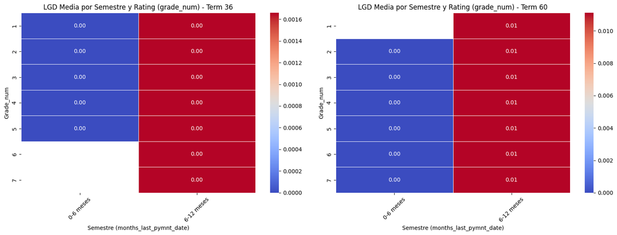

```python
# Filtrar datos para term = 36 y term = 60
lgd_term_36 = lgd_media_segmentos[lgd_media_segmentos["segmento_term"] == "36"]
lgd_term_60 = lgd_media_segmentos[lgd_media_segmentos["segmento_term"] == "60"]

# Crear figuras
fig, axes = plt.subplots(1, 2, figsize=(16, 6))

# Heatmap para term = 36
pivot_36 = lgd_term_36.pivot(index="grade_num", columns="segmento_meses", values="LGD_asignada")
sns.heatmap(pivot_36, annot=True, cmap="coolwarm", fmt=".2f", linewidths=0.5, ax=axes[0])
axes[0].set_title("LGD Media por Semestre y Rating (grade_num) - Term 36")
axes[0].set_xlabel("Semestre (months_last_pymnt_date)")
axes[0].set_ylabel("Grade_num")
axes[0].tick_params(axis='x', rotation=45)

# Heatmap para term = 60
pivot_60 = lgd_term_60.pivot(index="grade_num", columns="segmento_meses", values="LGD_asignada")
sns.heatmap(pivot_60, annot=True, cmap="coolwarm", fmt=".2f", linewidths=0.5, ax=axes[1])
axes[1].set_title("LGD Media por Semestre y Rating (grade_num) - Term 60")
axes[1].set_xlabel("Semestre (months_last_pymnt_date)")
axes[1].set_ylabel("Grade_num")
axes[1].tick_params(axis='x', rotation=45)

# Mostrar gráficos
plt.tight_layout()
plt.show()
```

Una vez que hemos demostrado las sospechas que teníamos inicialmente, no podemos asignar una LGD nula a la cartera de explotación porque estaríamos subestimando la pérdida esperada. Por ello, lo que vamos a calcular es la **LGD media obtenida para cada tramo de scoring, diferenciando si el plazo del préstamo es 36 o 60 meses**. Es decir, eliminamos la segmentación por la variable `months_last_pymnt_date`.

Calculamos la LGD media por segmento de score y plazo para el conjunto de construcción

```python
df_const.head(2)
```

|  | loan_amnt | funded_amnt | funded_amnt_inv | int_rate | installment | annual_inc | pymnt_plan | purpose | dti | delinq_2yrs | ... | months_last_pymnt_date | last_credit_pull_date | months_last_credit_pull_date | filtered_emp_title | zip_code_grouped | addr_state_grouped | loan_status | segmento_meses | segmento_term | LGD_asignada |
| --- | --- | --- | --- | --- | --- | --- | --- | --- | --- | --- | --- | --- | --- | --- | --- | --- | --- | --- | --- | --- | --- |
| 0 | 2500 | 2500 | 2500.0 | 15.27 | 59.83 | 30000.0 | n | car | 1.00 | 0.0 | ... | 16 | 2013-09-01 | 21 | other | 0 | 1 | Charged Off | 12-18 meses | 60 | 0.771429 |
| 1 | 5600 | 5600 | 5600.0 | 21.28 | 152.39 | 40000.0 | n | small_business | 5.55 | 0.0 | ... | 4 | 2012-08-01 | 8 | teacher | 0 | 1 | Charged Off | 0-6 meses | 60 | 0.0 |

2 rows × 52 columns

```python
tabla_lgd = (
    df_const
    .groupby(["grade_num", "segmento_term"])["LGD_asignada"]
    .mean()
    .reset_index()
    .rename(columns={"LGD_asignada": "LGD_asignada_media"})
)
```

Imputamos la LGD media calculada anteriormente, al conjunto de explotación

```python
df_explot = df_explot.merge(
    tabla_lgd,
    on=["grade_num", "segmento_term"],
    how="left"
)
```

```python
df_explot.head(2)
```

|  | loan_amnt | funded_amnt | funded_amnt_inv | int_rate | installment | annual_inc | pymnt_plan | purpose | dti | delinq_2yrs | ... | next_pymnt_date | months_next_pymnt_date | filtered_emp_title | zip_code_grouped | addr_state_grouped | loan_status | segmento_meses | segmento_term | LGD_asignada | LGD_asignada_media |
| --- | --- | --- | --- | --- | --- | --- | --- | --- | --- | --- | --- | --- | --- | --- | --- | --- | --- | --- | --- | --- | --- |
| 0 | 9000 | 9000 | 9000.0 | 6.24 | 274.78 | 52000.0 | n | credit_card | 16.87 | 0.0 | ... | 2016-02-01 | 4.0 | other | 0 | 0 | Charged Off | 0-6 meses | 36 | 0.0 | 0.355584 |
| 1 | 30000 | 30000 | 30000.0 | 12.69 | 677.85 | 82000.0 | n | debt_consolidation | 23.59 | 0.0 | ... | 2016-02-01 | 5.0 | healthcare | 0 | 0 | Charged Off | 0-6 meses | 60 | 0.0 | 0.594654 |

2 rows × 56 columns

Revisamos que no haya casos de LGD asignada media.

```python
df_explot["LGD_asignada_media"].isna().sum()
```

```
0
```

```python
df_explot["LGD_asignada_media"].mean()
```

```
0.4280738314235316
```

### 4. ASIGNACIÓN DE LGD A LOS PRÉSTAMOS EN SITUACIÓN NO "DEFAULT" O "CHARGED OFF"

```python
df_explot["LGD_asignada_media"].value_counts().sort_index()
```

```
LGD_asignada_media
0.235138      2
0.351396     68
0.352286      9
0.353303    215
0.355584    477
0.364566    487
0.36603     526
0.520392     27
0.533436      9
0.545357    128
0.557835     13
0.562105    182
0.594654    267
0.604978    178
Name: count, dtype: int64
```

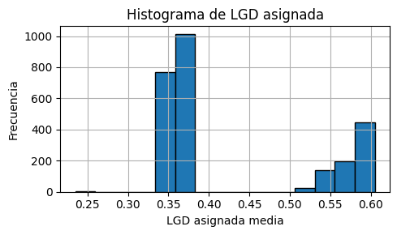

```python
plt.figure(figsize=(5, 3))
plt.hist(df_explot["LGD_asignada_media"], bins=15, edgecolor='black')
plt.title("Histograma de LGD asignada")
plt.xlabel("LGD asignada media")
plt.ylabel("Frecuencia")
plt.grid(True)
plt.tight_layout()
plt.show()
```

Descargamos el dataset de explotación con todos los préstamos (malos y buenos).

```python
features_explot = pd.read_csv('features_explot_PD.csv')
features_explot
```

|  | loan_amnt | funded_amnt | funded_amnt_inv | int_rate | installment | annual_inc | pymnt_plan | purpose | dti | delinq_2yrs | ... | months_earliest_cr_line_date | last_pymnt_date | months_last_pymnt_date | last_credit_pull_date | months_last_credit_pull_date | next_pymnt_date | months_next_pymnt_date | filtered_emp_title | zip_code_grouped | addr_state_grouped |
| --- | --- | --- | --- | --- | --- | --- | --- | --- | --- | --- | --- | --- | --- | --- | --- | --- | --- | --- | --- | --- | --- |
| 0 | 35000 | 35000 | 35000.0 | 11.99 | 778.38 | 128000.0 | n | home_improvement | 6.46 | 0.0 | ... | 310 | 2016-01-01 | 1 | 2016-01-01 | 1 | 2016-01-01 | 1.0 | customer_service | 0 | 1 |
| 1 | 8650 | 8650 | 8650.0 | 5.32 | 260.50 | 100000.0 | n | credit_card | 7.28 | 0.0 | ... | 173 | 2016-01-01 | 1 | 2016-01-01 | 1 | 2016-01-01 | 1.0 | support | 0 | 0 |
| 2 | 4225 | 4225 | 4225.0 | 14.85 | 146.16 | 35000.0 | n | debt_consolidation | 15.22 | 2.0 | ... | 53 | 2016-01-01 | 1 | 2016-01-01 | 1 | 2016-01-01 | 1.0 | technology | 0 | 0 |
| 3 | 10000 | 10000 | 10000.0 | 11.99 | 222.40 | 42500.0 | n | debt_consolidation | 31.04 | 0.0 | ... | 204 | 2016-01-01 | 1 | 2016-01-01 | 1 | 2016-01-01 | 1.0 | technology | 0 | 0 |
| 4 | 20000 | 20000 | 20000.0 | 10.78 | 432.66 | 63000.0 | n | home_improvement | 10.78 | 0.0 | ... | 184 | 2016-01-01 | 1 | 2015-12-01 | 0 | 2016-01-01 | 1.0 | operations | 0 | 0 |
| ... | ... | ... | ... | ... | ... | ... | ... | ... | ... | ... | ... | ... | ... | ... | ... | ... | ... | ... | ... | ... | ... |
| 402884 | 10000 | 10000 | 10000.0 | 11.99 | 332.10 | 31000.0 | n | debt_consolidation | 28.69 | 0.0 | ... | 124 | 2016-01-01 | 12 | 2016-01-01 | 12 | 2016-02-01 | 13.0 | support | 0 | 0 |
| 402885 | 24000 | 24000 | 24000.0 | 11.99 | 797.03 | 79000.0 | n | home_improvement | 3.90 | 0.0 | ... | 490 | 2016-01-01 | 12 | 2016-01-01 | 12 | 2016-02-01 | 13.0 | management | 0 | 0 |
| 402886 | 13000 | 13000 | 13000.0 | 15.99 | 316.07 | 35000.0 | n | debt_consolidation | 30.90 | 0.0 | ... | 136 | 2016-01-01 | 12 | 2016-01-01 | 12 | 2016-02-01 | 13.0 | other | 0 | 0 |
| 402887 | 12000 | 12000 | 12000.0 | 19.99 | 317.86 | 64400.0 | n | debt_consolidation | 27.19 | 1.0 | ... | 135 | 2016-01-01 | 12 | 2016-01-01 | 12 | 2016-02-01 | 13.0 | other | 0 | 0 |
| 402888 | 20000 | 20000 | 20000.0 | 11.99 | 664.20 | 100000.0 | n | credit_card | 10.83 | 0.0 | ... | 157 | 2016-01-01 | 12 | 2016-01-01 | 12 | 2016-02-01 | 13.0 | management | 0 | 0 |

402889 rows × 51 columns

```python
df_aux= pd.read_csv('loan_data_2015.csv')
```

Añadimos la variable objetivo al dataset de variables

```python
features_explot['loan_status'] = df_aux['loan_status']
```

Cambiamos el nombre al dataset con el que vamos a trabajar para no inducir a errores

```python
df_explot_total = features_explot
df_explot_total
```

|  | loan_amnt | funded_amnt | funded_amnt_inv | int_rate | installment | annual_inc | pymnt_plan | purpose | dti | delinq_2yrs | ... | last_pymnt_date | months_last_pymnt_date | last_credit_pull_date | months_last_credit_pull_date | next_pymnt_date | months_next_pymnt_date | filtered_emp_title | zip_code_grouped | addr_state_grouped | loan_status |
| --- | --- | --- | --- | --- | --- | --- | --- | --- | --- | --- | --- | --- | --- | --- | --- | --- | --- | --- | --- | --- | --- |
| 0 | 35000 | 35000 | 35000.0 | 11.99 | 778.38 | 128000.0 | n | home_improvement | 6.46 | 0.0 | ... | 2016-01-01 | 1 | 2016-01-01 | 1 | 2016-01-01 | 1.0 | customer_service | 0 | 1 | Issued |
| 1 | 8650 | 8650 | 8650.0 | 5.32 | 260.50 | 100000.0 | n | credit_card | 7.28 | 0.0 | ... | 2016-01-01 | 1 | 2016-01-01 | 1 | 2016-01-01 | 1.0 | support | 0 | 0 | Issued |
| 2 | 4225 | 4225 | 4225.0 | 14.85 | 146.16 | 35000.0 | n | debt_consolidation | 15.22 | 2.0 | ... | 2016-01-01 | 1 | 2016-01-01 | 1 | 2016-01-01 | 1.0 | technology | 0 | 0 | Issued |
| 3 | 10000 | 10000 | 10000.0 | 11.99 | 222.40 | 42500.0 | n | debt_consolidation | 31.04 | 0.0 | ... | 2016-01-01 | 1 | 2016-01-01 | 1 | 2016-01-01 | 1.0 | technology | 0 | 0 | Issued |
| 4 | 20000 | 20000 | 20000.0 | 10.78 | 432.66 | 63000.0 | n | home_improvement | 10.78 | 0.0 | ... | 2016-01-01 | 1 | 2015-12-01 | 0 | 2016-01-01 | 1.0 | operations | 0 | 0 | Issued |
| ... | ... | ... | ... | ... | ... | ... | ... | ... | ... | ... | ... | ... | ... | ... | ... | ... | ... | ... | ... | ... | ... |
| 402884 | 10000 | 10000 | 10000.0 | 11.99 | 332.10 | 31000.0 | n | debt_consolidation | 28.69 | 0.0 | ... | 2016-01-01 | 12 | 2016-01-01 | 12 | 2016-02-01 | 13.0 | support | 0 | 0 | Current |
| 402885 | 24000 | 24000 | 24000.0 | 11.99 | 797.03 | 79000.0 | n | home_improvement | 3.90 | 0.0 | ... | 2016-01-01 | 12 | 2016-01-01 | 12 | 2016-02-01 | 13.0 | management | 0 | 0 | Current |
| 402886 | 13000 | 13000 | 13000.0 | 15.99 | 316.07 | 35000.0 | n | debt_consolidation | 30.90 | 0.0 | ... | 2016-01-01 | 12 | 2016-01-01 | 12 | 2016-02-01 | 13.0 | other | 0 | 0 | In Grace Period |
| 402887 | 12000 | 12000 | 12000.0 | 19.99 | 317.86 | 64400.0 | n | debt_consolidation | 27.19 | 1.0 | ... | 2016-01-01 | 12 | 2016-01-01 | 12 | 2016-02-01 | 13.0 | other | 0 | 0 | Current |
| 402888 | 20000 | 20000 | 20000.0 | 11.99 | 664.20 | 100000.0 | n | credit_card | 10.83 | 0.0 | ... | 2016-01-01 | 12 | 2016-01-01 | 12 | 2016-02-01 | 13.0 | management | 0 | 0 | Current |

402889 rows × 52 columns

Eliminamos del conjunto de datos, los préstamos que están "Default" o "Charged Off", ya que son aquellos préstamos que hemos usado para el cálculo de la LGD

```python
df_explot_total = df_explot_total[~df_explot_total.loan_status.isin([
    "Charged Off",
    "Default",
    "Does not meet the credit policy. Status:Charged Off"
])]
```

```python
df_explot_total.shape
```

```
(400301, 52)
```

Mientras que nuestro dataset de construcción será el dataset calculado en los pasos anteriores de este notebook, llamado `df_explot`.

```python
df_construcción = df_explot
```

```python
df_construcción.shape, df_explot_total.shape
```

```
((2588, 56), (400301, 52))
```

Eliminamos las variables que no vamos a necesitar de cada conjunto.

```python
#construcción
df_construcción.drop(['loan_status', 'segmento_meses', 'segmento_term', 'LGD_asignada'], axis=1, inplace=True)
```

```python
#explotación
df_explot_total.drop("loan_status", axis=1, inplace=True)
```

```python
df_construcción.shape, df_explot_total.shape
```

```
((2588, 52), (400301, 51))
```

**Separación entre features y target**

```python
features = df_construcción.drop(columns=["LGD_asignada_media"])
target = df_construcción['LGD_asignada_media']
```

**Eliminamos las variables fecha** de ambos dataset

```python
features.drop(['earliest_cr_line_date', 'issue_date','last_pymnt_date','last_credit_pull_date'], axis=1, inplace=True)
```

```python
df_explot_total.drop(['earliest_cr_line_date', 'issue_date','last_pymnt_date','last_credit_pull_date'], axis=1, inplace=True)
```

**Normalizar**

```python
numeric_columns_const = features.select_dtypes(include=['number']).columns
```

```python
numeric_columns_explot = df_explot_total.select_dtypes(include=['number']).columns
```

```python
#Definimos el escalador
scaler = MinMaxScaler()
```

```python
#Normalizamos variables numéricas
features[numeric_columns_const] = scaler.fit_transform(features[numeric_columns_const])
df_explot_total[numeric_columns_explot] = scaler.fit_transform(df_explot_total[numeric_columns_explot])
```

**Aplicar one-hot encoding**

Construcción

```python
#Seleccionamos las variables categóricas
categorical_columns_const = features.select_dtypes(include=['object']).columns

#Aplicamos One-Hot Encoding sólo a las variables categóricas
one_hot_encoded_const= pd.get_dummies(features[categorical_columns_const], drop_first=True)   #drop_first=True: Elimina la primera categoría de cada columna para evitar colinealidad.

# Combinar el resultado con el DataFrame original excluyendo las columnas categóricas originales
df_const = pd.concat([features.drop(columns=categorical_columns_const), one_hot_encoded_const], axis=1)
```

Explotación

```python
#Seleccionamos las variables categóricas
categorical_columns_explot = df_explot_total.select_dtypes(include=['object']).columns

#Aplicamos One-Hot Encoding sólo a las variables categóricas
one_hot_encoded_explot= pd.get_dummies(df_explot_total[categorical_columns_explot], drop_first=True)   #drop_first=True: Elimina la primera categoría de cada columna para evitar colinealidad.

# Combinar el resultado con el DataFrame original excluyendo las columnas categóricas originales
df_explot = pd.concat([df_explot_total.drop(columns=categorical_columns_explot), one_hot_encoded_explot], axis=1)
```

```python
df_const
```

|  | loan_amnt | funded_amnt | funded_amnt_inv | int_rate | installment | annual_inc | dti | delinq_2yrs | inq_last_6mths | open_acc | ... | filtered_emp_title_operator | filtered_emp_title_other | filtered_emp_title_ownership | filtered_emp_title_project_management | filtered_emp_title_sales | filtered_emp_title_security | filtered_emp_title_senior | filtered_emp_title_specialist | filtered_emp_title_support | filtered_emp_title_technology |
| --- | --- | --- | --- | --- | --- | --- | --- | --- | --- | --- | --- | --- | --- | --- | --- | --- | --- | --- | --- | --- | --- |
| 0 | 0.235294 | 0.235294 | 0.235294 | 0.044359 | 0.197065 | 0.081671 | 0.421961 | 0.000000 | 0.0 | 0.00 | ... | False | True | False | False | False | False | False | False | False | False |
| 1 | 0.852941 | 0.852941 | 0.852941 | 0.355352 | 0.524602 | 0.138126 | 0.590045 | 0.000000 | 0.2 | 0.42 | ... | False | False | False | False | False | False | False | False | False | False |
| 2 | 0.205882 | 0.205882 | 0.205882 | 0.225169 | 0.183511 | 0.066616 | 0.740370 | 0.000000 | 0.4 | 0.18 | ... | False | True | False | False | False | False | False | False | False | False |
| 3 | 0.252941 | 0.252941 | 0.252941 | 0.000000 | 0.208710 | 0.119307 | 0.256378 | 0.000000 | 0.2 | 0.16 | ... | False | False | False | False | False | False | False | False | False | False |
| 4 | 0.676471 | 0.676471 | 0.676471 | 0.137898 | 0.586538 | 0.200226 | 0.390695 | 0.000000 | 0.0 | 0.28 | ... | False | False | False | False | False | False | False | False | False | False |
| ... | ... | ... | ... | ... | ... | ... | ... | ... | ... | ... | ... | ... | ... | ... | ... | ... | ... | ... | ... | ... | ... |
| 2583 | 0.069118 | 0.069118 | 0.069118 | 0.321601 | 0.064188 | 0.028980 | 0.645323 | 0.000000 | 0.0 | 0.04 | ... | False | False | False | False | False | False | False | False | True | False |
| 2584 | 0.411765 | 0.411765 | 0.411765 | 0.161524 | 0.224856 | 0.062853 | 0.412456 | 0.066667 | 0.0 | 0.32 | ... | False | True | False | False | False | False | False | False | False | False |
| 2585 | 0.397059 | 0.397059 | 0.397059 | 0.402122 | 0.374546 | 0.096726 | 0.470735 | 0.000000 | 0.0 | 0.18 | ... | False | False | False | False | False | False | False | False | False | False |
| 2586 | 0.411765 | 0.411765 | 0.411765 | 0.056413 | 0.347307 | 0.171998 | 0.309655 | 0.000000 | 0.0 | 0.22 | ... | False | False | False | False | False | False | False | False | False | False |
| 2587 | 0.676471 | 0.676471 | 0.676471 | 0.104629 | 0.580338 | 0.435454 | 0.095548 | 0.000000 | 0.2 | 0.20 | ... | False | False | False | False | False | False | False | False | True | False |

2588 rows × 74 columns

```python
df_explot
```

|  | loan_amnt | funded_amnt | funded_amnt_inv | int_rate | installment | annual_inc | dti | delinq_2yrs | inq_last_6mths | open_acc | ... | filtered_emp_title_operator | filtered_emp_title_other | filtered_emp_title_ownership | filtered_emp_title_project_management | filtered_emp_title_sales | filtered_emp_title_security | filtered_emp_title_senior | filtered_emp_title_specialist | filtered_emp_title_support | filtered_emp_title_technology |
| --- | --- | --- | --- | --- | --- | --- | --- | --- | --- | --- | --- | --- | --- | --- | --- | --- | --- | --- | --- | --- | --- |
| 0 | 1.000000 | 1.000000 | 1.000000 | 0.281791 | 0.528679 | 0.013474 | 0.000646 | 0.000000 | 0.000000 | 0.197531 | ... | False | False | False | False | False | False | False | False | False | False |
| 1 | 0.225000 | 0.225000 | 0.227273 | 0.000000 | 0.162774 | 0.010526 | 0.000728 | 0.000000 | 0.000000 | 0.172840 | ... | False | False | False | False | False | False | False | False | True | False |
| 2 | 0.094853 | 0.094853 | 0.097507 | 0.402619 | 0.081987 | 0.003684 | 0.001522 | 0.051282 | 0.000000 | 0.061728 | ... | False | False | False | False | False | False | False | False | False | True |
| 3 | 0.264706 | 0.264706 | 0.266862 | 0.281791 | 0.135854 | 0.004474 | 0.003104 | 0.000000 | 0.166667 | 0.111111 | ... | False | False | False | False | False | False | False | False | False | True |
| 4 | 0.558824 | 0.558824 | 0.560117 | 0.230672 | 0.284412 | 0.006632 | 0.001078 | 0.000000 | 0.000000 | 0.061728 | ... | False | False | False | False | False | False | False | False | False | False |
| ... | ... | ... | ... | ... | ... | ... | ... | ... | ... | ... | ... | ... | ... | ... | ... | ... | ... | ... | ... | ... | ... |
| 402884 | 0.264706 | 0.264706 | 0.266862 | 0.281791 | 0.213362 | 0.003263 | 0.002869 | 0.000000 | 0.000000 | 0.098765 | ... | False | False | False | False | False | False | False | False | True | False |
| 402885 | 0.676471 | 0.676471 | 0.677419 | 0.281791 | 0.541856 | 0.008316 | 0.000390 | 0.000000 | 0.166667 | 0.049383 | ... | False | False | False | False | False | False | False | False | False | False |
| 402886 | 0.352941 | 0.352941 | 0.354839 | 0.450782 | 0.202036 | 0.003684 | 0.003090 | 0.000000 | 0.000000 | 0.098765 | ... | False | True | False | False | False | False | False | False | False | False |
| 402887 | 0.323529 | 0.323529 | 0.325513 | 0.619772 | 0.203301 | 0.006779 | 0.002719 | 0.025641 | 0.333333 | 0.197531 | ... | False | True | False | False | False | False | False | False | False | False |
| 402888 | 0.558824 | 0.558824 | 0.560117 | 0.281791 | 0.448005 | 0.010526 | 0.001083 | 0.000000 | 0.166667 | 0.086420 | ... | False | False | False | False | False | False | False | False | False | False |

400301 rows × 78 columns

**Separación entre X_train e y_train**

```python
X_train, X_test, y_train, y_test = train_test_split(
    df_const,             # Features
    target,               # Variable objetivo
    test_size=0.2,        # 20% para test
    random_state=42       # Para reproducibilidad
)
```

```python
X_train.shape, X_test.shape
```

```
((2070, 74), (518, 74))
```

```python
model = XGBRegressor(
    n_estimators=200,
    learning_rate=0.05,
    max_depth=4,
    subsample=0.8,
    colsample_bytree=0.8,
    random_state=42
)
```

```python
model.fit(X_train, y_train)
```

```
XGBRegressor(base_score=None, booster=None, callbacks=None,
             colsample_bylevel=None, colsample_bynode=None,
             colsample_bytree=0.8, device=None, early_stopping_rounds=None,
             enable_categorical=False, eval_metric=None, feature_types=None,
             gamma=None, grow_policy=None, importance_type=None,
             interaction_constraints=None, learning_rate=0.05, max_bin=None,
             max_cat_threshold=None, max_cat_to_onehot=None,
             max_delta_step=None, max_depth=4, max_leaves=None,
             min_child_weight=None, missing=nan, monotone_constraints=None,
             multi_strategy=None, n_estimators=200, n_jobs=None,
             num_parallel_tree=None, random_state=42, ...)
```

Se obtiene un R2 casi perfecto

```python
scores = cross_val_score(model, X_train, y_train, scoring='r2', cv=5) #neg_mean_absolute_error
print("R2 promedio (CV):", scores.mean())
```

```
R2 promedio (CV): 0.9977178642792168
```

```python
df_explot.shape, X_train.shape
```

```
((400301, 78), (2070, 74))
```

Antes de predecir, vamos a asegurarnos que tenemos las mismas features en explotación que en entrenamiento

```python
df_explot = df_explot[X_train.columns]
```

Predecir sobre el conjunto de explotación

```python
df_explot['LGD_estimada'] = model.predict(df_explot)
```

Obtenemos una LGD media de la cartera para el conjunto de explotación de 43%, lo cuál está en línea con la LGD del conjunto de explotación

```python
df_explot['LGD_estimada'].mean()
```

```
0.43138245
```

```python
df_explot['LGD_estimada'].describe()
```

```
count    400301.000000
mean          0.431382
std           0.100791
min           0.235826
25%           0.362637
50%           0.366011
75%           0.555696
max           0.613858
Name: LGD_estimada, dtype: float64
```

Observamos una distribución bimodal. Esto puede deberse a una clusterización natural en 2 segmentos claramente diferenciados (por score, tipo de cliente, importe, etc).

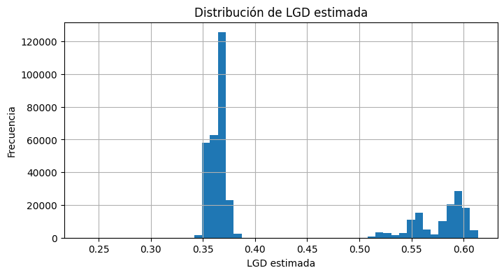

```python
df_explot['LGD_estimada'].hist(bins=50, figsize=(8, 4))
plt.title("Distribución de LGD estimada")
plt.xlabel("LGD estimada")
plt.ylabel("Frecuencia")
plt.grid(True)
plt.show()
```

Observamos que esa distribución bimodal ya existía en el conjunto de origen. Esta bimodalidad puede deberse a como construimos el conjunto de construcción, ya que lo llevamos a cabo segmentando por score del cliente y por plazo de préstanos (36 o 60 meses),y tal y como pudimos apreciar en la construcción, el plazo afecta a la recuperación del préstamo:

- Los préstamos a 36 meses tienen menor LGD porque se pagan más rápido.
- Los préstamos a 60 meses tienen mayor LGD porque existe mayor probabilidad de deterioro.

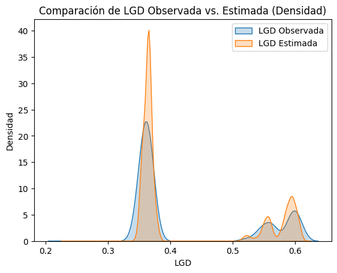

```python
sns.kdeplot(df_construcción['LGD_asignada_media'], label="LGD Observada", shade=True, bw_adjust=0.5)
sns.kdeplot(df_explot['LGD_estimada'], label="LGD Estimada", shade=True, bw_adjust=0.5)

plt.title("Comparación de LGD Observada vs. Estimada (Densidad)")
plt.xlabel("LGD")
plt.ylabel("Densidad")
plt.legend()
plt.show()
```

Vamos a concatenar el conjunto de datos que usamos en construcción, con el dataset que acabamos de estimar.

```python
df_const.shape, target.shape
```

```
((2588, 74), (2588,))
```

```python
df_const = pd.concat([df_const, target], axis=1)
```

```python
df_const.rename(columns={'LGD_asignada_media': 'LGD_estimada'}, inplace=True)
```

```python
df_total_LGD = pd.concat([df_const, df_explot], axis=0)
```

```python
df_total_LGD.shape
```

```
(402889, 75)
```

Guardamos el dataset creado

```python
df_total_LGD.to_csv("df_explot_LGD_estimada.csv")
```